# Tidying datasets

Víctor Peña

Throughout, we will use functions in `library(tidyr)` and `library(dplyr)`.

## `gather`: from wide to long format

Suppose you want to compare outcomes with 3 treatments, and your data look like this

```r
data
```

```
## # A tibble: 5 x 3
##   Treat1 Treat2 Treat3
##    <dbl>  <dbl>  <dbl>
## 1 -1.60   0.983 -0.2
## 2  0.409 -0.671 -0.022
## 3 -0.019 -0.313 -1.74
## 4 -0.251  3.25   1.88
## 5  0.306  2.06  -0.083
```

Some people would say that the data is in “wide format.”

Data in wide format aren’t convenient for running our analyses: if you want to run an ANOVA or Tukey, you need to have all the outcomes in one column, and the categories (treatments) in another column. This alternative formatting is called “long format”. You can go from wide to long format using `gather` in `library(tidyr)`.

```r
data %>% gather(key=treatment, value=outcome, Treat1, Treat2, Treat3)
```

```
## # A tibble: 15 x 2
##    treatment outcome
##    <chr>       <dbl>
##  1 Treat1     -1.60
##  2 Treat1      0.409
##  3 Treat1     -0.019
##  4 Treat1     -0.251
##  5 Treat1      0.306
##  6 Treat2      0.983
##  7 Treat2     -0.671
##  8 Treat2     -0.313
##  9 Treat2      3.25
## 10 Treat2      2.06
## 11 Treat3     -0.2
## 12 Treat3     -0.022
## 13 Treat3     -1.74
## 14 Treat3      1.88
## 15 Treat3     -0.083
```

The first argument in `gather` is for naming the new column that contains the categories (the `key`), the second one is for naming the column where the new outcomes will be stored (the `value`), and then you write the names of the columns that contain the outcomes you want to `gather`. An equivalent way of writing the same thing is:

```r
data %>% gather(key=treatment, value=outcome, Treat1:Treat3)
```

```
## # A tibble: 15 x 2
##    treatment outcome
##    <chr>       <dbl>
##  1 Treat1     -1.60
##  2 Treat1      0.409
##  3 Treat1     -0.019
##  4 Treat1     -0.251
##  5 Treat1      0.306
##  6 Treat2      0.983
##  7 Treat2     -0.671
##  8 Treat2     -0.313
##  9 Treat2      3.25
## 10 Treat2      2.06
## 11 Treat3     -0.2
## 12 Treat3     -0.022
## 13 Treat3     -1.74
## 14 Treat3      1.88
## 15 Treat3     -0.083
```

In `Treat1:Treat3` we gave `R` a range of columns which we want to `gather` (first to last). This is useful if you have many variables.

What if your data is in wide format, but you have an uneven number of observations? That is, your data looks something like this

```r
uneven
```

```
## # A tibble: 5 x 3
##    Treat1 Treat2  Treat3
##     <dbl>  <dbl>   <dbl>
## 1  -1.60   0.983  -0.2
## 2   0.409 -0.671  -0.022
## 3  -0.019 -0.313  -1.74
## 4  -0.251  3.25   NA
## 5  NA      2.06   NA
```

Let’s try to `gather`:

```r
uneven %>% gather(key = treatment, value = outcome, Treat1:Treat3)
```

```
## # A tibble: 15 x 2
##    treatment outcome
##    <chr>       <dbl>
##  1 Treat1     -1.60
##  2 Treat1      0.409
##  3 Treat1     -0.019
##  4 Treat1     -0.251
##  5 Treat1     NA
##  6 Treat2      0.983
##  7 Treat2     -0.671
##  8 Treat2     -0.313
##  9 Treat2      3.25
## 10 Treat2      2.06
## 11 Treat3     -0.2
## 12 Treat3     -0.022
## 13 Treat3     -1.74
## 14 Treat3     NA
## 15 Treat3     NA
```

Unfortunately, we get some `NA`s. We can get rid of them with `na.omit`:

```r
uneven %>% gather(key = treatment, value = outcome, Treat1:Treat3) %>%
           na.omit
```

```
## # A tibble: 12 x 2
##    treatment outcome
##    <chr>       <dbl>
##  1 Treat1     -1.60
##  2 Treat1      0.409
##  3 Treat1     -0.019
##  4 Treat1     -0.251
##  5 Treat2      0.983
##  6 Treat2     -0.671
##  7 Treat2     -0.313
##  8 Treat2      3.25
##  9 Treat2      2.06
## 10 Treat3     -0.2
## 11 Treat3     -0.022
## 12 Treat3     -1.74
```

## `spread`: from long to wide format

If you want to go from long to wide format, you can use `spread`.

For example, if your data are

```r
data2
```

```
## # A tibble: 15 x 3
## # Groups:   treatment [3]
##    treatment outcome   ind
##    <chr>       <dbl> <int>
##  1 Treat1     -1.60      1
##  2 Treat1      0.409     2
##  3 Treat1     -0.019     3
##  4 Treat1     -0.251     4
##  5 Treat1      0.306     5
##  6 Treat2      0.983     1
##  7 Treat2     -0.671     2
##  8 Treat2     -0.313     3
##  9 Treat2      3.25      4
## 10 Treat2      2.06      5
## 11 Treat3     -0.2       1
## 12 Treat3     -0.022     2
## 13 Treat3     -1.74      3
## 14 Treat3      1.88      4
## 15 Treat3     -0.083     5
```

You can convert it to wide format as follows

```r
data2 %>% spread(treatment, outcome)
```

```
## # A tibble: 5 x 4
##     ind Treat1 Treat2 Treat3
##   <int>  <dbl>  <dbl>  <dbl>
## 1     1 -1.60   0.983 -0.2
## 2     2  0.409 -0.671 -0.022
## 3     3 -0.019 -0.313 -1.74
## 4     4 -0.251  3.25   1.88
## 5     5  0.306  2.06  -0.083
```

Note that `data2` isn’t just our dataset that came out of `gather`ing. In fact, if you start with

```r
gath = data %>% gather(key=treatment, value=outcome, Treat1:Treat3)
```

and you try to `spread`, you’ll get an error. `R` complains because the rows of `gath` aren’t uniquely identifiable. A way to get around that is creating index variables within the treatments

```r
gath = gath %>% group_by(treatment) %>% mutate(id=row_number())
gath
```

```
## # A tibble: 15 x 3
## # Groups:   treatment [3]
##    treatment outcome    id
##    <chr>       <dbl> <int>
##  1 Treat1     -1.60      1
##  2 Treat1      0.409     2
##  3 Treat1     -0.019     3
##  4 Treat1     -0.251     4
##  5 Treat1      0.306     5
##  6 Treat2      0.983     1
##  7 Treat2     -0.671     2
##  8 Treat2     -0.313     3
##  9 Treat2      3.25      4
## 10 Treat2      2.06      5
## 11 Treat3     -0.2       1
## 12 Treat3     -0.022     2
## 13 Treat3     -1.74      3
## 14 Treat3      1.88      4
## 15 Treat3     -0.083     5
```

and then, you can `spread` (and get rid of `id`):

```r
gath %>% spread(treatment, outcome) %>% select(-id)
```

```
## # A tibble: 5 x 3
##   Treat1 Treat2 Treat3
##    <dbl>  <dbl>  <dbl>
## 1 -1.60   0.983 -0.2
## 2  0.409 -0.671 -0.022
## 3 -0.019 -0.313 -1.74
## 4 -0.251  3.25   1.88
## 5  0.306  2.06  -0.083
```

## `unite` variables

Suppose you have the following dataset

```r
drinks
```

```
## # A tibble: 6 x 3
##   spirit         mixer        total
##   <chr>          <chr>        <dbl>
## 1 gin            tonic            8
## 2 sparkling wine orange juice     6
## 3 rum            coke             7
## 4 red wine       coke             5
## 5 <NA>           seltzer          5
## 6 beer           <NA>             5
```

If you would like to create a new column that merges the information in `spirit` and `mixer`, you can use the command `unite`.

For example, you can try

```r
drinks %>% unite(name, spirit, mixer, sep=' & ')
```

```
## # A tibble: 6 x 2
##   name                          total
##   <chr>                         <dbl>
## 1 gin & tonic                       8
## 2 sparkling wine & orange juice     6
## 3 rum & coke                        7
## 4 red wine & coke                   5
## 5 NA & seltzer                      5
## 6 beer & NA                         5
```

Unfortunately, it doesn’t look great because there are `NA`s. You can substitute the `NA`s by `nothing` using `coalesce` to make the output look a little nicer:

```r
new = drinks %>%
        mutate(spirit=coalesce(spirit, "nothing"), mixer=coalesce(mixer, "nothing")) %>%
        unite(name, spirit, mixer, sep=' & ') %>%
        mutate(name=trimws(name))
new
```

```
## # A tibble: 6 x 2
##   name                          total
##   <chr>                         <dbl>
## 1 gin & tonic                       8
## 2 sparkling wine & orange juice     6
## 3 rum & coke                        7
## 4 red wine & coke                   5
## 5 nothing & seltzer                 5
## 6 beer & nothing                    5
```

The function `trimws` got rid of some empty spaces at the beginning and end of `name`.

If you are willing to work a little bit more, you can make the new variable look even nicer:

```r
final = new %>% mutate(name1 = gsub("& nothing","",name),
                       name = trimws(gsub("nothing &","",name1))) %>%
                       select(-name1)
final
```

```
## # A tibble: 6 x 2
##   name                          total
##   <chr>                         <dbl>
## 1 gin & tonic                       8
## 2 sparkling wine & orange juice     6
## 3 rum & coke                        7
## 4 red wine & coke                   5
## 5 seltzer                           5
## 6 beer                              5
```

We used the function `gsub` to substitute `& nothing` and `nothing &` by (literally) nothing.

## `separate` variables

You can split up variables using `separate`. For example, if you start with

```
## # A tibble: 6 x 2
##   name                          total
##   <chr>                         <dbl>
## 1 gin & tonic                       8
## 2 sparkling wine & orange juice     6
## 3 rum & coke                        7
## 4 red wine & coke                   5
## 5 nothing & seltzer                 5
## 6 beer & nothing                    5
```

We can split up `name` into `spirit` and `mixer` with

```r
new %>% separate(name, into=c("spirit", "mixer"), sep=" & ")
```

```
## # A tibble: 6 x 3
##   spirit         mixer        total
##   <chr>          <chr>        <dbl>
## 1 gin            tonic            8
## 2 sparkling wine orange juice     6
## 3 rum            coke             7
## 4 red wine       coke             5
## 5 nothing        seltzer          5
## 6 beer           nothing          5
```

If you use the dataset `final` instead, you would have to do more work to `separate` correctly.

## Summarizing what you know with `gapminder`

The dataset `gapminder` in `library(gapminder)` has information on life expectancy, GDP per capita, and population for some countries. The variables are

```r
str(gapminder)
```

```
## Classes 'tbl_df', 'tbl' and 'data.frame':    1704 obs. of  6 variables:
##  $ country  : Factor w/ 142 levels "Afghanistan",..: 1 1 1 1 1 1 1 1 1 1 ...
##  $ continent: Factor w/ 5 levels "Africa","Americas",..: 3 3 3 3 3 3 3 3 3 3 ...
##  $ year     : int  1952 1957 1962 1967 1972 1977 1982 1987 1992 1997 ...
##  $ lifeExp  : num  28.8 30.3 32 34 36.1 ...
##  $ pop      : int  8425333 9240934 10267083 11537966 13079460 14880372 12881816 13867957 16317921 22227415 ...
##  $ gdpPercap: num  779 821 853 836 740 ...
```

We can find the average life expectancy by continent and year with

```r
out = gapminder %>%
  group_by(continent, year) %>%
  summarize(avglife=mean(lifeExp))
out
```

```
## # A tibble: 60 x 3
## # Groups:   continent [?]
##    continent  year avglife
##    <fct>     <int>   <dbl>
##  1 Africa     1952    39.1
##  2 Africa     1957    41.3
##  3 Africa     1962    43.3
##  4 Africa     1967    45.3
##  5 Africa     1972    47.5
##  6 Africa     1977    49.6
##  7 Africa     1982    51.6
##  8 Africa     1987    53.3
##  9 Africa     1992    53.6
## 10 Africa     1997    53.6
## # ... with 50 more rows
```

And you can plot the trends as follows:

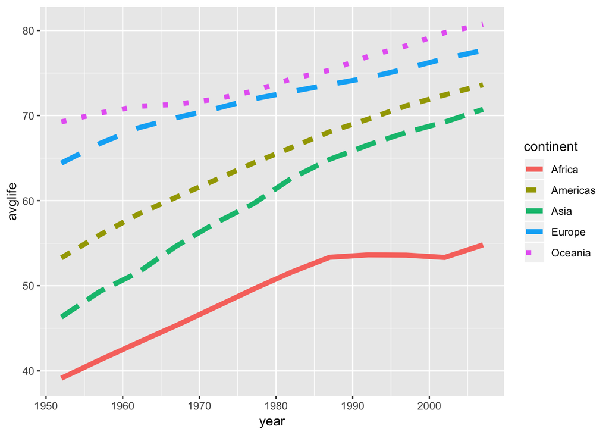

```r
ggplot(out, aes(x=year, y=avglife, color=continent, linetype=continent))+geom_line(size=2)
```

What’s going on in Oceania? Let’s find out:

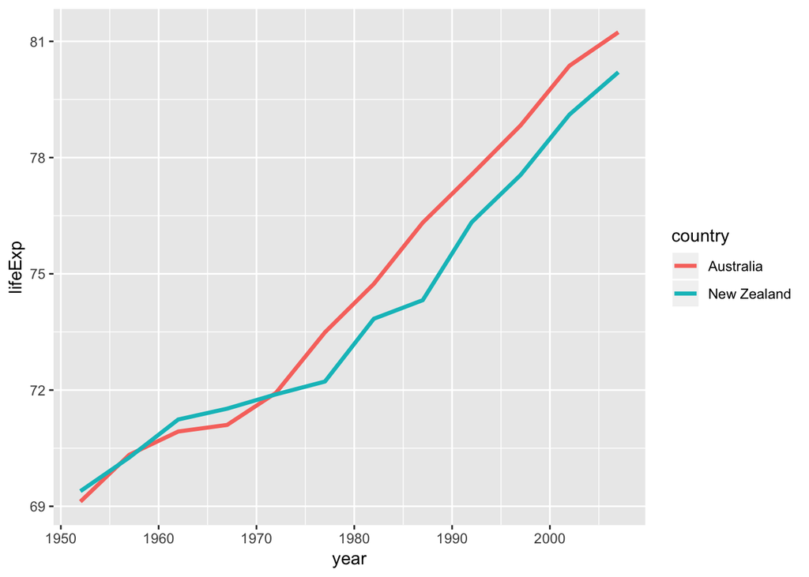

```r
out2 = gapminder %>%
  filter(continent == "Oceania")
ggplot(out2, aes(x=year, y=lifeExp, color=country)) + geom_line(size=1.2)
```

```r
gapminder %>% select(country, year, pop) %>%
          filter(year==1952|year==2007)  %>%
          spread(key=year, value=pop) %>%
          mutate(diffPop = `2007`-`1952`) %>%
          select(country, diffPop) %>%
          arrange(diffPop)
```

```
## # A tibble: 142 x 2
##    country               diffPop
##    <fct>                   <int>
##  1 Bulgaria                47958
##  2 Sao Tome and Principe  139568
##  3 Iceland                153969
##  4 Montenegro             270902
##  5 Equatorial Guinea      334237
##  6 Trinidad and Tobago    393758
##  7 Djibouti               433225
##  8 Hungary                452108
##  9 Slovenia               519727
## 10 Reunion                540394
## # ... with 132 more rows
```

Notice the backticks in the variables when you define `diffPop`.

## Resources

- [`tidyr` youbsite](https://tidyr.tidyverse.org/)
- [Tutorial by Bradley Boehmke](https://rpubs.com/bradleyboehmke/data_wrangling)
- [Tutorial by Olivia L. Holmes](https://ademos.people.uic.edu/Chapter9.html)